# Heart Stroke Analysis - Summary Report

# 1 Chapter 1: Introduction

## 1.1 Why Heart Stroke Prediction ? Prior research and analysis.

A heart attack, also known as a stroke, it happens when something prevents the blood flow to a certain area of the heart or when a blood artery in the heart leaks. In 2020, stroke was the cause of 1 in 6 fatalities from cardiovascular disease. A stroke occurs in the United States every 40 seconds. One person has a stroke and dies every 3.5 minutes. In the US, there are more than 795,000 stroke victims annually. Of these, about 610,000 are new or first strokes. Nearly 1 in 4 strokes, or about 185,000, occur among persons who have already experienced a stroke. Ischemic strokes account for around 87% of all strokes. Stroke is one of the leading causes of death and disability in the USA. Anyone can have a stroke, regardless of their age, gender, or background. According to the US Department of Health and Human Services’ National Institutes of Health (NIH), 795,000 people in the US have strokes annually, and 137,000 of them will die. According to the World Health Organization (WHO), stroke is the second most common cause of death worldwide, accounting for roughly 11% of all fatalities.

Most cardiovascular diseases can be prevented by addressing behavioral risk factors such as tobacco use, unhealthy diet and obesity, physical inactivity using population-wide strategies. People with cardiovascular disease or who are at high cardiovascular risk (due to the presence of one or more risk factors such as hypertension, diabetes or already established disease) need early detection and management wherein a machine learning model can be of great help.

Reference: WHO

# 2 Chapter 2: Description of the Data

## 2.1 Source of the Data

Presently, our dataset has a total of 4,238 observations across 16 variables. (See below for a readout of the dataset’s structure and variable names). Variable descriptions and additional information on the dataset comes from the following: [Data Source](https://www.kaggle.com/datasets/dileep070/heart-disease-prediction-using-logistic-regression).

```
## 'data.frame':    4238 obs. of  16 variables:
##  $ male           : int  1 0 1 0 0 0 0 0 1 1 ...
##  $ age            : int  39 46 48 61 46 43 63 45 52 43 ...
##  $ education      : int  4 2 1 3 3 2 1 2 1 1 ...
##  $ currentSmoker  : int  0 0 1 1 1 0 0 1 0 1 ...
##  $ cigsPerDay     : int  0 0 20 30 23 0 0 20 0 30 ...
##  $ BPMeds         : int  0 0 0 0 0 0 0 0 0 0 ...
##  $ prevalentStroke: int  0 0 0 0 0 0 0 0 0 0 ...
##  $ prevalentHyp   : int  0 0 0 1 0 1 0 0 1 1 ...
##  $ diabetes       : int  0 0 0 0 0 0 0 0 0 0 ...
##  $ totChol        : int  195 250 245 225 285 228 205 313 260 225 ...
##  $ sysBP          : num  106 121 128 150 130 ...
##  $ diaBP          : num  70 81 80 95 84 110 71 71 89 107 ...
##  $ BMI            : num  27 28.7 25.3 28.6 23.1 ...
##  $ heartRate      : int  80 95 75 65 85 77 60 79 76 93 ...
##  $ glucose        : int  77 76 70 103 85 99 85 78 79 88 ...
##  $ TenYearCHD     : int  0 0 0 1 0 0 1 0 0 0 ...
```

[output not shown]

## 2.2 Data Manipulation and Cleaning

- Factorizing the character value columns into categorical values, and numerical values based on the type of the column.
- Checking for Null values in the dataset.
- Null value imputation with mean for all the columns contains null values due to less number of observations.
- subsetting the data into people who got stroke and the ones that didn’t .
- subsetting the data into male and females who got stroke .
- created a separate categorical column for BMI using the bucketing system given in [Wikipedia](https://en.wikipedia.org/wiki/Body_mass_index).
- created a separate categorical column for average glucose level and age.
- Renaming the target variable from TenYearCHD to stroke.

For our exploratory data analysis, we ignored education because this is an independent variable and has no relationship with stroke.

Table : Statistical Summary after cleaning

|  | gender | age | education | currentSmoker | cigsPerDay | BPMeds | prevalentStroke | prevalentHyp | diabetes | totChol | sysBP | diaBP | BMI | heartRate | glucose | stroke |
| --- | --- | --- | --- | --- | --- | --- | --- | --- | --- | --- | --- | --- | --- | --- | --- | --- |
| Min | F:2419 | Min. :32.0 | Min. :1.00 | 0:2144 | Min. : 0 | 0:4114 | 0:4213 | 0:2922 | 0:4129 | Min. :107 | Min. : 83.5 | Min. : 48.0 | Min. :15.5 | Min. : 44.0 | Min. : 40 | 0:3594 |
| Q1 | M:1819 | 1st Qu.:42.0 | 1st Qu.:1.00 | 1:2094 | 1st Qu.: 0 | 1: 124 | 1: 25 | 1:1316 | 1: 109 | 1st Qu.:206 | 1st Qu.:117.0 | 1st Qu.: 75.0 | 1st Qu.:23.1 | 1st Qu.: 68.0 | 1st Qu.: 72 | 1: 644 |
| Median | NA | Median :49.0 | Median :2.00 | NA | Median : 0 | NA | NA | NA | NA | Median :234 | Median :128.0 | Median : 82.0 | Median :25.4 | Median : 75.0 | Median : 80 | NA |
| Mean | NA | Mean :49.6 | Mean :1.95 | NA | Mean : 9 | NA | NA | NA | NA | Mean :237 | Mean :132.4 | Mean : 82.9 | Mean :25.8 | Mean : 75.9 | Mean : 82 | NA |
| Q3 | NA | 3rd Qu.:56.0 | 3rd Qu.:3.00 | NA | 3rd Qu.:20 | NA | NA | NA | NA | 3rd Qu.:262 | 3rd Qu.:144.0 | 3rd Qu.: 89.9 | 3rd Qu.:28.0 | 3rd Qu.: 83.0 | 3rd Qu.: 85 | NA |
| Max | NA | Max. :70.0 | Max. :4.00 | NA | Max. :70 | NA | NA | NA | NA | Max. :696 | Max. :295.0 | Max. :142.5 | Max. :56.8 | Max. :143.0 | Max. :394 | NA |

## 2.3 Distribution of the predictor variables

### 2.3.1 Density plot of Age

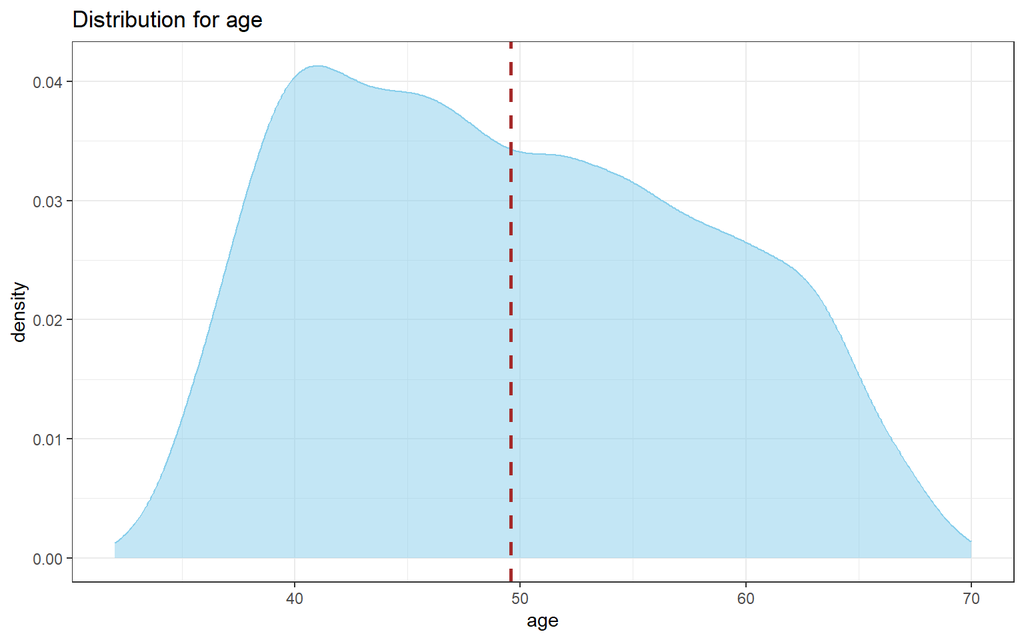

This density plot is showing a smooth line which represents the density of age values in our dataset. The higher the peak of the line, the more values there are in that range. Conversely, the lower the peak, the fewer values there are in that range.

### 2.3.2 Density plot for BMI

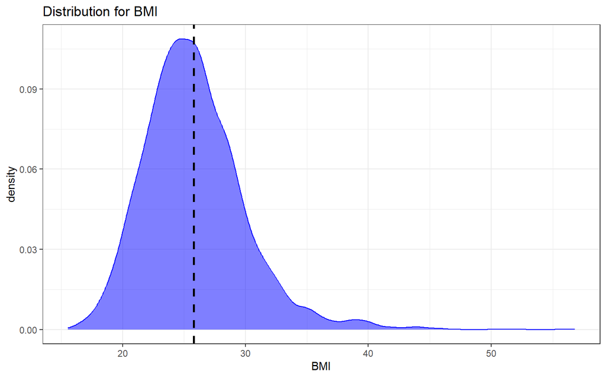

This density plot depicts a smooth curve which represents the density of BMI values in our dataset. The higher the peak of the line, the more values there are in that range. Conversely, the lower the peak, the fewer values there are in that range. From this plot, within the BMI range of 20 to 30, with a peak value of 26 BMI, more observations are recorded.

### 2.3.3 Density plot for Glucose

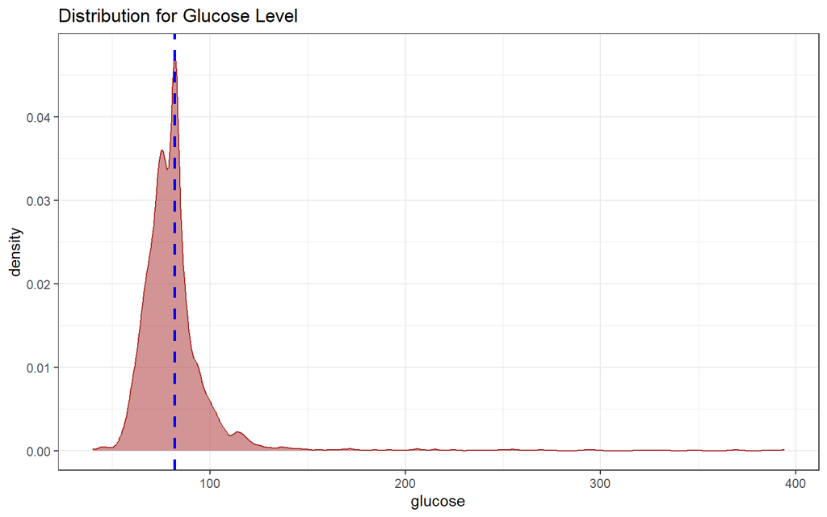

The above density plot represents the distribution of glucose level of all the patients in the dataset. The x-axis ranges from 50 to 400 and the density as y-axis. sFrom this density curve, majority of the observations are recorded below the glucose level of 100 with a peak value at 80.

### 2.3.4 Bar plot for distribution of Males and Females in the Dataset

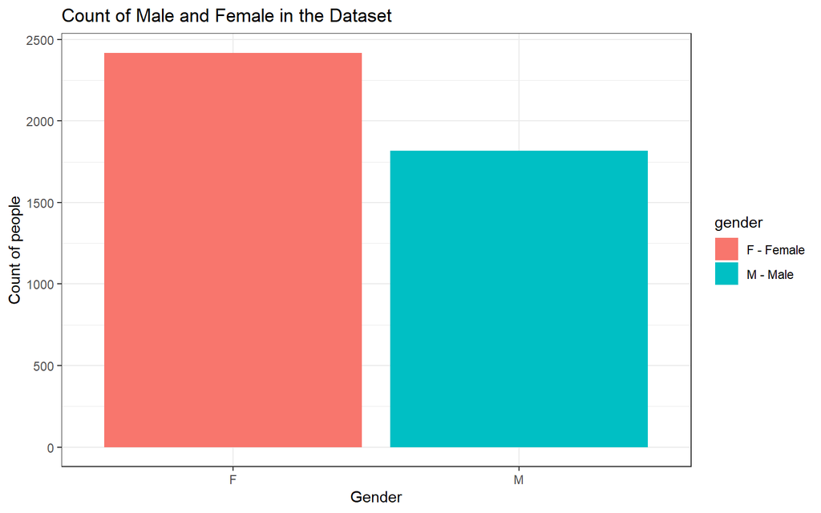

This bar chart represents the gender distribution of all the patients in the dataset. It shows the count of male and female patients. We have around 2400 female records and 1800 male records in the dataframe.

## 2.4 Distribution of Stroke (Target variable)

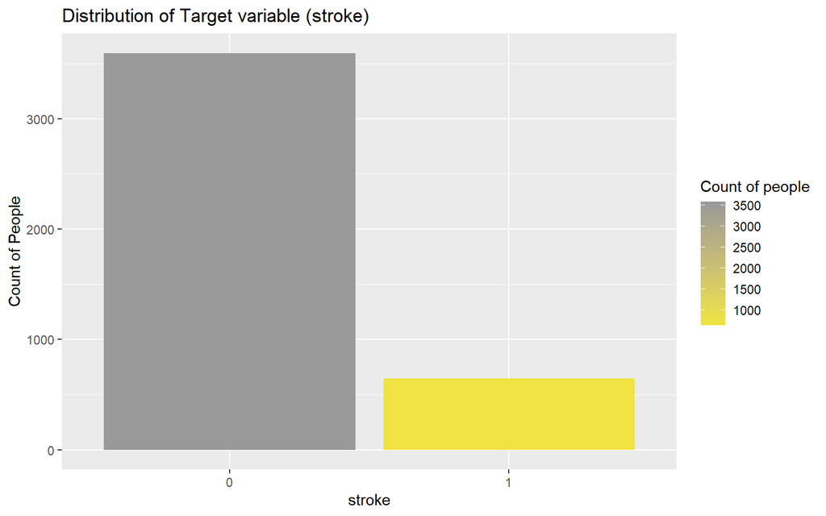

# 3 Chapter 3: Exploratory Data Analysis & SMART Questions:

## 3.1 Can the type of gender and smoking habbit of an individual cause stroke?

**NULL HYPOTHESIS**  
**H0: There is no dependency between gender + currentSmoker on stroke variable. Thus gender and currentSmoker are independent of stroke**  
**H1: There is significant dependency between gender + currentSmoker on stroke variable. Thus gender and currentSmoker are dependent of stroke**

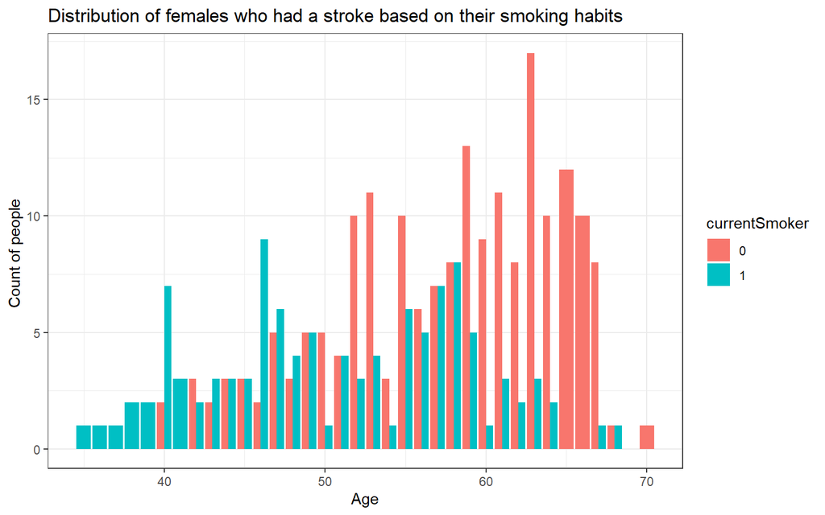

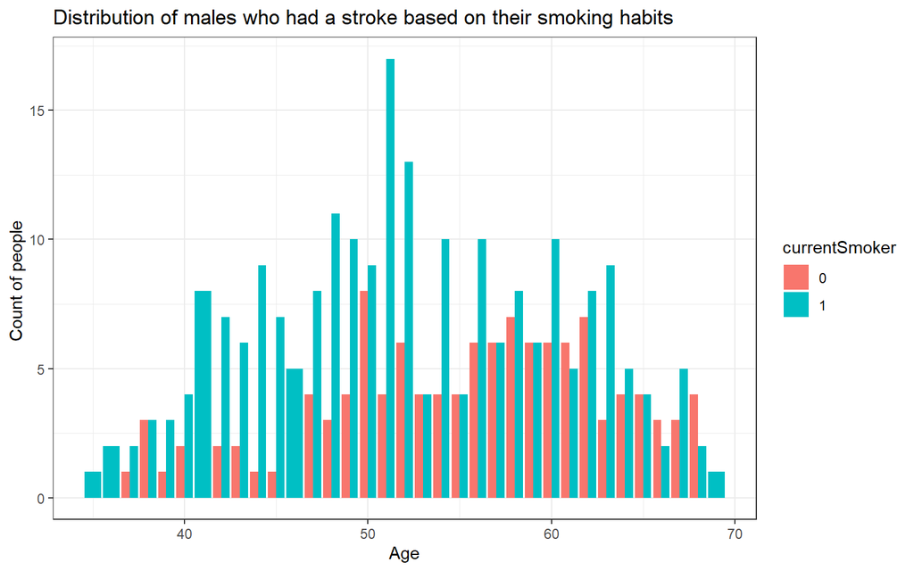

```
##
##  Pearson's Chi-squared test with Yates' continuity correction
##
## data:  dat$currentSmoker and dat$stroke
## X-squared = 1, df = 1, p-value = 0.2
```

```
##
##  Pearson's Chi-squared test with Yates' continuity correction
##
## data:  dat$gender and dat$stroke
## X-squared = 33, df = 1, p-value = 0.00000001
```

## 3.2 Does aging really cause stroke?

**NULL HYPOTHESIS**  
**H0: There is no change in the mean of age with respect to stroke**  
**H1: The mean of age is changing with respect to stroke**

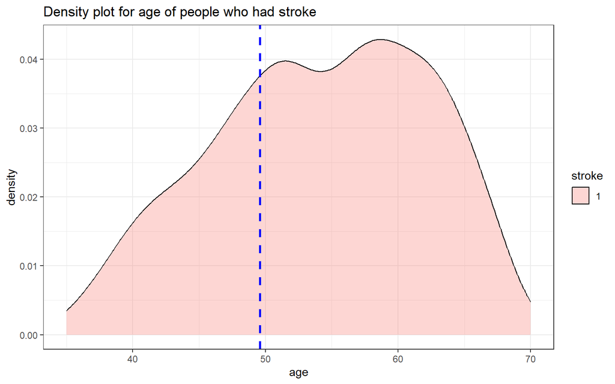

We chose the ANOVA test because we wanted to examine if age played a role in a person suffering from stroke.

```
##               Df Sum Sq Mean Sq F value              Pr(>F)
## stroke         1  15798   15798     226 <0.0000000000000002 ***
## Residuals   4236 295545      70
## ---
## Signif. codes:  0 '***' 0.001 '**' 0.01 '*' 0.05 '.' 0.1 ' ' 1
```

The ANOVA test result indicates that the p value is less than 0.05 and it is very significant. Hence we fail to accept the null hypothesis which implies that as age increases, the likelihood of having a stroke increases.

## 3.3 Does aging with any other features increase the chances of getting a stroke?

### 3.3.1 Does BMI with age affect stroke?

**NULL HYPOTHESIS**  
**H0: BMI is independent of stroke**  
**H1: BMI is dependent of stroke**

As we saw in our previous analysis, the likelihood of someone having a stroke increases with age. We also wondered if other factors, such as BMI and average glucose level, affect a person’s chances of having a stroke as they age.

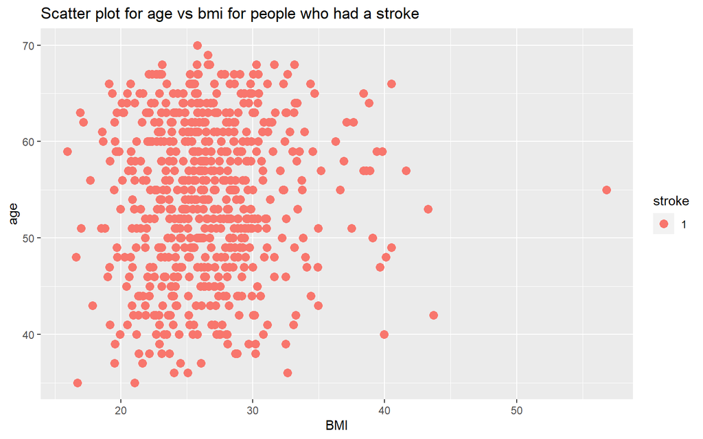

Since the previous scatter plot provided a rough estimate of where the majority of the strokes occurred. We decided to divide these BMI into different categories based on the information provided by [Wikipedia](https://en.wikipedia.org/wiki/Body_mass_index)

The categories are encoded as:

- Underweight - BMI < 18.5
- Normal - BMI >= 18.5 and BMI <= 25
- Overweight - BMI >= 25.0 and BMI <= 30
- Obesity - BMI >= 30.0 and BMI < 40
- “Extreme” or Severe Obesity - BMI >= 40

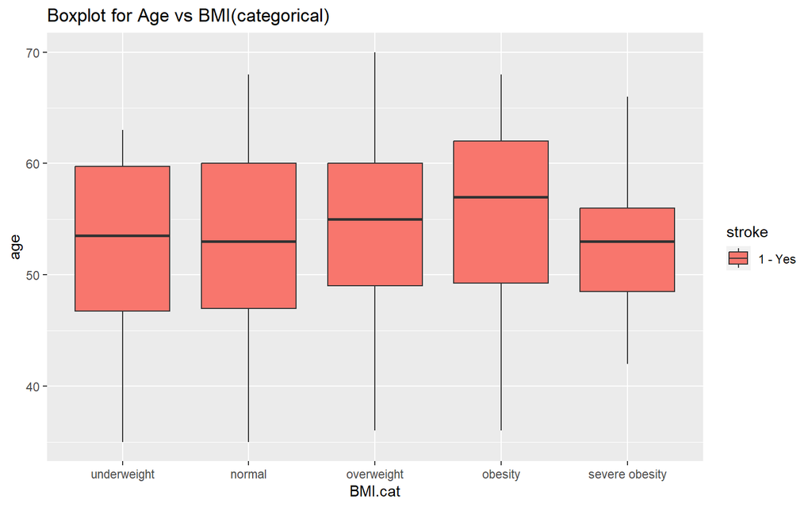

```
##
##  Welch Two Sample t-test
##
## data:  BMI by stroke
## t = -4, df = 834, p-value = 0.000008
## alternative hypothesis: true difference in means between group 0 and group 1 is not equal to 0
## 95 percent confidence interval:
##  -1.218 -0.476
## sample estimates:
## mean in group 0 mean in group 1
##            25.7            26.5
```

As we can see from the t test, the p-value is less than 0.05, So we fail to accept the null hypothesis and can conclude that BMI is correlated with stroke.

### 3.3.2 Does Average glucose level with age affect stroke?

**NULL HYPOTHESIS**  
**H0: Average glucose level is independent of stroke**  
**H1: Average glucose level is dependent of stroke**

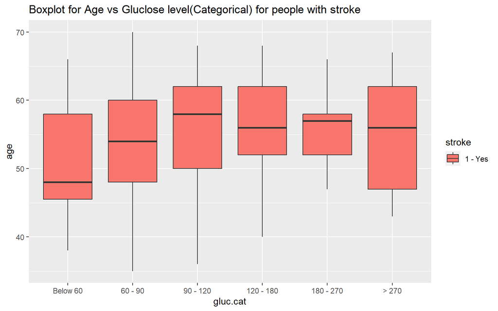

Since we can see that average glucose level in the body along with age is somehow affecting the chances of a person having a stroke. From our previous analysis we can say that age definitely has an affect on stroke, now we are going to look if the average glucose level has any effect on stroke using chi-squared test.

```
##
##  Pearson's Chi-squared test
##
## data:  dat$gluc.cat and dat$stroke
## X-squared = 79, df = 5, p-value = 0.000000000000001
```

We can see from this test that the p-value is less than 0.05, so we cannot accept the null hypothesis and can conclude that average glucose level is dependent on stroke.

### 3.3.3 Can Hypertension be a reason for an individual to suffer from a stroke?

**NULL HYPOTHESIS**  
**H0: Hypertension is independent of stroke**  
**H1: Hypertension is dependent of stroke**

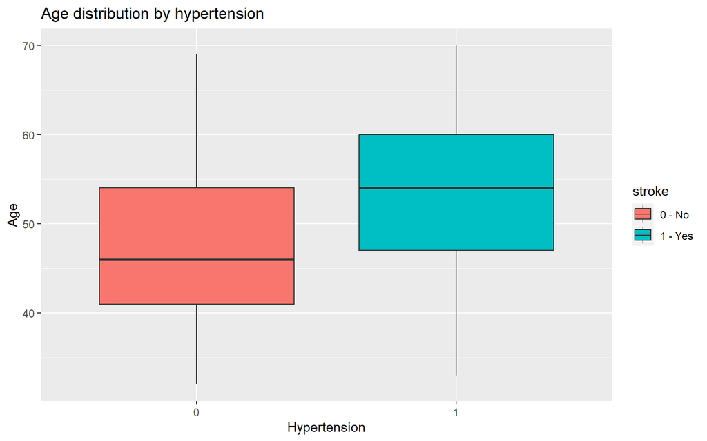

This Box plot that we created for the combination of hypertension and age (the person who was affected by heart stroke), where hypertension - 0 represents people who did not have hypertension and hypertension-1 represents people who did have hypertension.

According to the graph,those who in the age netween 50 to 60 years and those with hypertension are more likely to have a heart attack.

A major risk factor for stroke is high blood pressure. High Blood Pressure makes your heart work harder and gradually damages your organs and arteries. You are more prone to get a stroke due to hypertension as you age. So as the age increases the chances of getting hypertension for an individual is higher which leads to stroke.

Ref: [link](https://www.stroke.org/-/media/Stroke-Files/Lets-Talk-About-Stroke/Risk-Factors/Stroke-and-High-Blood-Pressure-ucm_493407.pdf).

```
##
##  Pearson's Chi-squared test with Yates' continuity correction
##
## data:  stroke_df$prevalentHyp and stroke_df$stroke
## X-squared = 133, df = 1, p-value <0.0000000000000002
```

As we can observe that the p-value is less than 0.05, we fail to accept the null hypothesis and hence we can conclude that hypertension is dependent of stroke.

### 3.3.4 How sysBP and diaBP along with age groups together cause stroke?

**NULL HYPOTHESIS**  
**H0: sysBP and diaBP is independent of stroke**  
**H1: sysBP and diaBP is dependent of stroke**

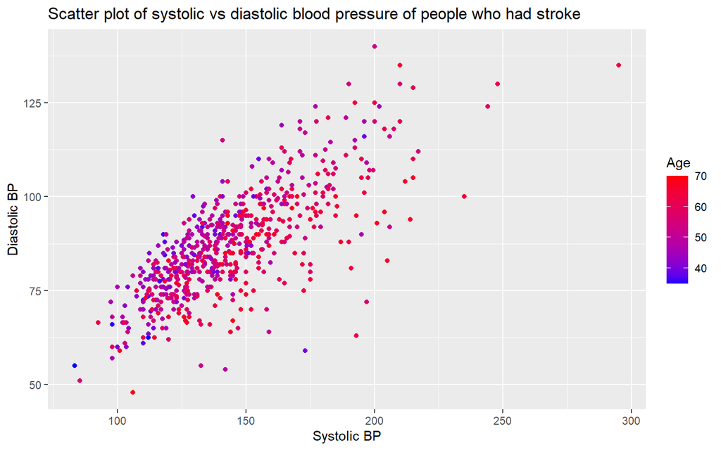

```r
ggplot(dat_1, aes(x = sysBP, y = diaBP, color = age)) +
  geom_point() +
  labs(
    title = "Scatter plot of systolic vs diastolic blood pressure of people who had stroke",
    x = "Systolic BP",
    y = "Diastolic BP",
    color = "Age"
  ) +
  scale_color_gradient(low = "blue", high = "red")
```

This scatter plot depicts the relationship between Systolic Blood pressure and Diastolic Blood pressure in stroke patients.

In the plot, the x-axis (Systolic BP) ranges from 50 to 300 and y-axis (Diastolic BP) ranges from 50 to 150.

Ref: [link](https://www.cdc.gov/stroke/risk_factors.htm#:~:text=Heart%20disease,rich%20blood%20to%20the%20brain.).

```
##
##  Welch Two Sample t-test
##
## data:  sysBP by stroke
## t = -12, df = 784, p-value <0.0000000000000002
## alternative hypothesis: true difference in means between group 0 and group 1 is not equal to 0
## 95 percent confidence interval:
##  -15.5 -11.1
## sample estimates:
## mean in group 0 mean in group 1
##             130             144
```

```
##
##  Welch Two Sample t-test
##
## data:  diaBP by stroke
## t = -8, df = 800, p-value = 0.0000000000000006
## alternative hypothesis: true difference in means between group 0 and group 1 is not equal to 0
## 95 percent confidence interval:
##  -5.97 -3.67
## sample estimates:
## mean in group 0 mean in group 1
##            82.2            87.0
```

As we can observe that the p-value is less than 0.05, we fail to accept the null hypothesis and hence we can conclude that sysBP and diaBP is dependent of stroke.

# 4 Chapter 4: Conclusion

This summary paper shows exploratory data analysis of various variables such as stroke, age, currentSmoker (Smoking status), prevalentStroke, BMI, Hypertension, and so on. The cleaned data will be used again, and the model will be trained on it. We discovered the factors (variables) that cause stroke and took them into account based on the analysis. Our long-term goal is to develop the best model that can predict if a person can suffer from a stroke based on the current dataset we have.

# 5 Chapter 5: Limitations

There are a few limitations in our dataset because the number of datapoints is very low (approximately 4300 rows) also target variable is an imbalanced data column which requires techniques (over and under sampling methods) in order to convert into balanced data, and it would be preferable if there were more datapoints for people who have suffered from stroke so that the analyses performed on this data can be applied to a larger population. Other factors such as previous stress level, stroke history in the family, cholesterol imbalance, and physical inactivity could have been more useful in predicting the likelihood of someone having a stroke.

# 6 Chapter 6: References

World Health Organization. (2021, May 17). Cardiovascular diseases (CVDs). Fact Sheet. https://www.who.int/en/news-room/fact-sheets/detail/cardiovascular-diseases-(cvds)

Dataset: Dileep, K. (2020). Heart Disease Prediction using Logistic Regression. Kaggle. https://www.kaggle.com/dileep070/heart-disease-prediction-using-logistic-regression

Body Mass Index reference: Wikipedia contributors. (2023, March 22). In Wikipedia, from https://en.wikipedia.org/wiki/Body_mass_index

United States health records of BP and stroke: American Stroke Association. (n.d.). Stroke and High Blood Pressure. [PDF] https://www.stroke.org/-/media/Stroke-Files/Lets-Talk-About-Stroke/Risk-Factors/Stroke-and-High-Blood-Pressure-ucm_493407.pdf

Stroke Risk Factors.: Centers for Disease Control and Prevention. (2022, January 5) from https://www.cdc.gov/stroke/risk_factors.htm#:~:text=Heart%20disease,rich%20blood%20to%20the%20brain.